# Лабораторная работа №5

Операционные системы

Кайнова А. А.

Российский университет дружбы народов, Москва, Россия

16 марта 2024

# Цель работы

Настроить рабочую среду: менеджер паролей pass, установка доп ПО, chezmoi.

# Задание

1. Установить и наcтроить менеджер паролей pass.
2. Установить дополнительное ПО.
3. Установить и настроить chezmoi

# Теоретическое введение

Менеджер паролей pass — программа, сделанная в рамках идеологии Unix. Также носит название стандартного менеджера паролей для Unix (The standard Unix password manager). Данные хранятся в файловой системе в виде каталогов и файлов. Файлы шифруются с помощью GPG-ключа.Структура базы может быть произвольной, если Вы собираетесь использовать её напрямую, без промежуточного программного обеспечения. Тогда семантику структуры базы данных Вы держите в своей голове. Если же необходимо использовать дополнительное программное обеспечение, необходимо семантику заложить в структуру базы паролей.

# Выполнение лабораторной работы

## Установить и настроить менеджер паролей pass

Установим pass

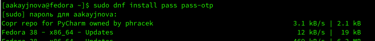

Установка менеджера паролей

Просмотрим список ключей gpg

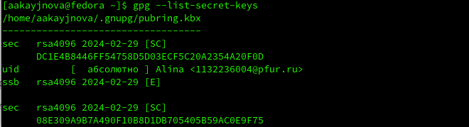

Список ключей

## Установить и настроить менеджер паролей pass

Инициализируем хранилище

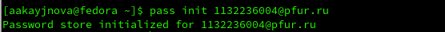

Инициализация хранилища

Создадим структуру git

## Установить и настроить менеджер паролей pass

Зададим адрес репозитория на хостинге

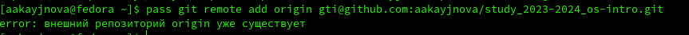

Задание адреса репозитория

Проверим статус синхронизации

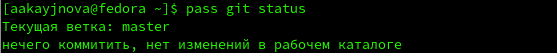

Статус синхронизации

## Установить и настроить менеджер паролей pass

Установи плагин browserpass для Firefox

[figure not shown]

Установка browserpass для Firefox

Подключиться к репозиторию для установки интерфейса для взаимодейтвия с броузером не удалось.

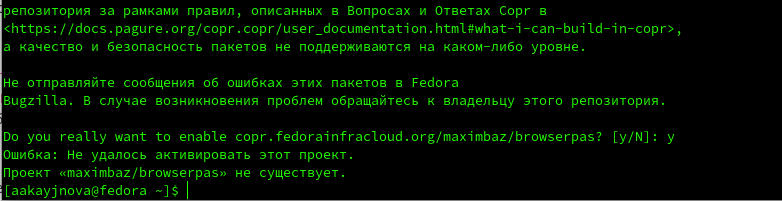

Интерфейс для броузера

Соответственно, не удалось установить и browserpass.

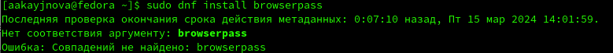

Browserpass

Поэтому мне пришлось устанавливать интерфейс для browserpass с помощью сторонних ресурсов.

## Установить и настроить менеджер паролей pass

Добавим новый пароль

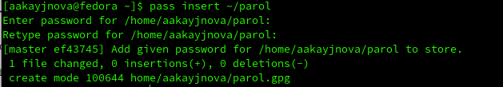

Добавление пароля

Отобразим созданный пароль

## Установить и настроить менеджер паролей pass

Заменим существующий пароль на рандомно сгенерированный и отобразим его

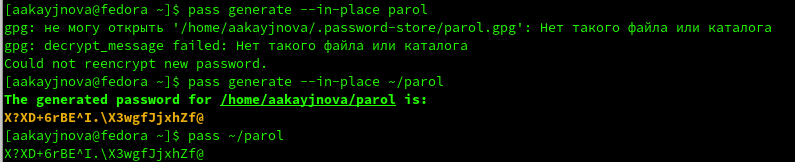

Генерация пароля

## Установить допольнительное ПО

Установим dunst

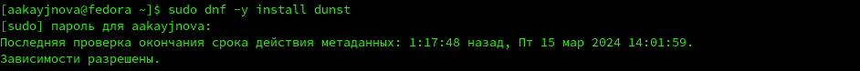

Установка dunst

Установим fontawesome-fonts

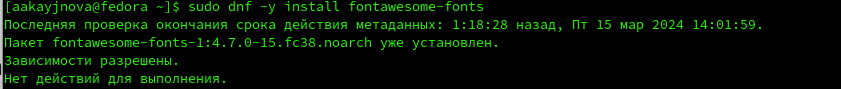

Установка fontawesome-fonts

## Установить допольнительное ПО

Установим powerline-fonts

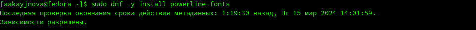

Установка powerline-fonts

Установим light

## Установить допольнительное ПО

Установим fuzzel

Установим swaylock

## Установить допольнительное ПО

Установим kitty

Установим waybar swaybg

## Установить допольнительное ПО

Установим wl-clipboard

Установим mpv

## Установить допольнительное ПО

Установим grim

Установим slurp

## Установить допольнительное ПО

Подключимся к репозиторию Copr

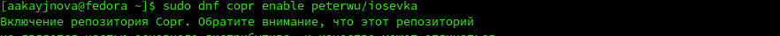

Подключение к Copr

Поиск iosevka

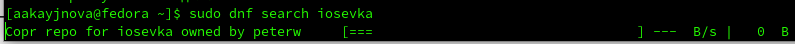

Поиск iosevka

Установим заданные шрифты

## Установить и настроить chezmoi

Установим бинарный файл для определения архитектуры процессора и скачивания необходимого файла

Создадим репозиторий для конфигурационных файлов на основе шаблона

## Установить и настроить chezmoi

Инициализируем chezmoi с нашим репозиторием doftiles

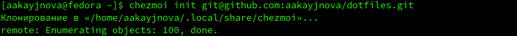

Инициализация репозитория

Проверим изменения, которые внесёт chezmoi в домашний каталог и примем измения

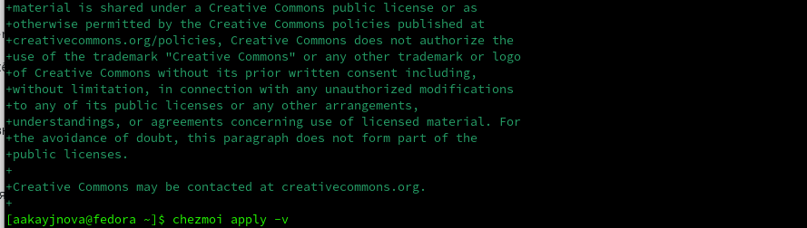

Проверка и одобрение изменений

## Установить и настроить chezmoi

Получим и применим последние изменения chezmoi

Применим последние изменения

## Установить и настроить chezmoi

Откроем файл конфигурации chezmoi.toml

У меня изначально всё было true

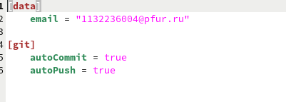

Файл конфигурации

# Выводы

В ходе данной лабораторной работы мы настроили свою рабочую среду для дальнешей работы.

# Список литературы

1. https://esystem.rudn.ru/mod/page/view.php?id=1098796